# Travel Package Purchase Prediction Project

# 3. Data Pre-Processing

### Dropping certain columns

```python
# Dropping CustomerID column as all values in the column are unique
cust1.drop(["CustomerID"], axis=1, inplace=True)
```

```python
# Dropping certain columns related to Customer Interaction data, as this columns do not add value
# to the prediction of a future product.

cust1.drop(
    [
        "PitchSatisfactionScore",
        "ProductPitched",
        "NumberOfFollowups",
        "DurationOfPitch",
    ],
    axis=1,
    inplace=True,
)
```

```python
# Dropping NumberOfChildrenVisiting, as it is highly correlated to NumberOfPersonVisiting
cust1.drop(
    ["NumberOfChildrenVisiting"], axis=1, inplace=True,
)
```

### Correcting possible Data Errors in Gender Column

```python
# Changing 'Fe Male' values to 'Female' in Gender column
cust1["Gender"] = cust1["Gender"].apply(lambda x: x.replace("Fe Male", "Female"))
```

### Outlier Detection and Treatment (for Monthly Income and NumberOfTrips)

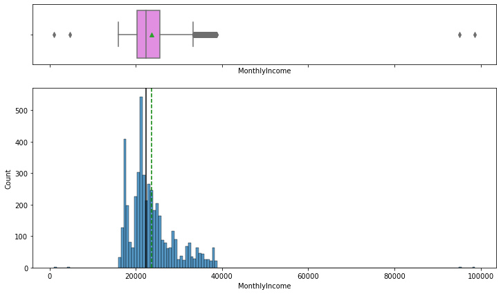

```python
# before outlier treatment
histogram_boxplot(cust1, "MonthlyIncome")
```

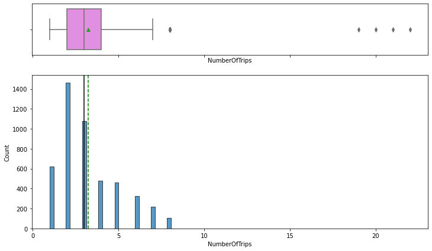

```python
# before outlier treatment
histogram_boxplot(cust1, "NumberOfTrips")
```

```python
# functions to treat outliers by flooring and capping


def treat_outliers(df, col):
    """
    Treats outliers in a variable

    df: dataframe
    col: dataframe column
    """
    Q1 = df[col].quantile(0.25)  # 25th quantile
    Q3 = df[col].quantile(0.75)  # 75th quantile
    IQR = Q3 - Q1
    Lower_Whisker = Q1 - 1.5 * IQR
    Upper_Whisker = Q3 + 1.5 * IQR

    # all the values smaller than Lower_Whisker will be assigned the value of Lower_Whisker
    # all the values greater than Upper_Whisker will be assigned the value of Upper_Whisker
    df[col] = np.clip(df[col], Lower_Whisker, Upper_Whisker)

    return df


def treat_outliers_all(df, col_list):
    """
    Treat outliers in a list of variables

    df: dataframe
    col_list: list of dataframe columns
    """
    for c in col_list:
        df = treat_outliers(df, c)

    return df
```

```python
# Applying Outlier function
outlier_cols = ["MonthlyIncome", "NumberOfTrips"]
cust1 = treat_outliers_all(cust1, outlier_cols)
```

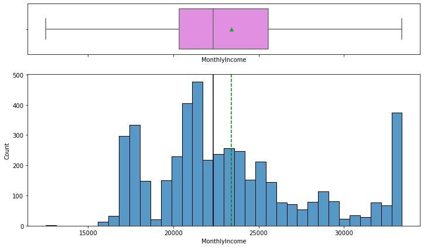

```python
# After Outlier Treatment
histogram_boxplot(cust1, "MonthlyIncome")
```

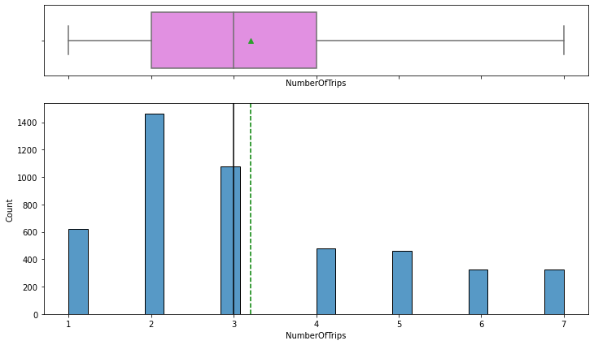

```python
# After Outlier Treatment
histogram_boxplot(cust1, "NumberOfTrips")
```

Observation

- Outliers have been treated in both columns, MonythlyIncome and NumberOfTrips

### Treatment of NULL values

```python
cust1.info()
```

```
<class 'pandas.core.frame.DataFrame'>
RangeIndex: 4888 entries, 0 to 4887
Data columns (total 14 columns):
 #   Column                  Non-Null Count  Dtype
---  ------                  --------------  -----
 0   ProdTaken               4888 non-null   int64
 1   Age                     4662 non-null   float64
 2   TypeofContact           4863 non-null   object
 3   CityTier                4888 non-null   int64
 4   Occupation              4888 non-null   object
 5   Gender                  4888 non-null   object
 6   NumberOfPersonVisiting  4888 non-null   int64
 7   PreferredPropertyStar   4862 non-null   float64
 8   MaritalStatus           4888 non-null   object
 9   NumberOfTrips           4748 non-null   float64
 10  Passport                4888 non-null   int64
 11  OwnCar                  4888 non-null   int64
 12  Designation             4888 non-null   object
 13  MonthlyIncome           4655 non-null   float64
dtypes: float64(4), int64(5), object(5)
memory usage: 534.8+ KB
```

```python
cat_cols = [
    "TypeofContact",
    "Occupation",
    "Gender",
    "MaritalStatus",
    "Designation",
]

for column in cat_cols:
    print(cust1[column].value_counts())
    print("-" * 30)
```

```
Self Enquiry       3444
Company Invited    1419
Name: TypeofContact, dtype: int64
------------------------------
Salaried          2368
Small Business    2084
Large Business     434
Free Lancer          2
Name: Occupation, dtype: int64
------------------------------
Male      2916
Female    1972
Name: Gender, dtype: int64
------------------------------
Married      2340
Divorced      950
Single        916
Unmarried     682
Name: MaritalStatus, dtype: int64
------------------------------
Executive         1842
Manager           1732
Senior Manager     742
AVP                342
VP                 230
Name: Designation, dtype: int64
------------------------------
```

```python
cust1.dropna(subset=["TypeofContact"], inplace=True)
```

```python
cust1.isna().sum()  # Check for NULL values on specific columns
```

```
ProdTaken                   0
Age                       226
TypeofContact               0
CityTier                    0
Occupation                  0
Gender                      0
NumberOfPersonVisiting      0
PreferredPropertyStar      26
MaritalStatus               0
NumberOfTrips             140
Passport                    0
OwnCar                      0
Designation                 0
MonthlyIncome             208
dtype: int64
```

```python
cust1.median()
```

```
ProdTaken                     0.0
Age                          36.0
CityTier                      1.0
NumberOfPersonVisiting        3.0
PreferredPropertyStar         3.0
NumberOfTrips                 3.0
Passport                      0.0
OwnCar                        1.0
MonthlyIncome             22347.0
dtype: float64
```

```python
cust1["Age"].fillna((cust1["Age"].mean()), inplace=True)
cust1["PreferredPropertyStar"].fillna(
    (cust1["PreferredPropertyStar"].mean()), inplace=True
)
cust1["NumberOfTrips"].fillna((cust1["NumberOfTrips"].mean()), inplace=True)
cust1["MonthlyIncome"].fillna((cust1["MonthlyIncome"].mean()), inplace=True)
```

```python
cust1.isna().sum()  # Check for NULL values on specific columns
```

```
ProdTaken                 0
Age                       0
TypeofContact             0
CityTier                  0
Occupation                0
Gender                    0
NumberOfPersonVisiting    0
PreferredPropertyStar     0
MaritalStatus             0
NumberOfTrips             0
Passport                  0
OwnCar                    0
Designation               0
MonthlyIncome             0
dtype: int64
```

```python
for feature in cust1.columns:  # Loop through all columns in the dataframe
    if (
        cust1[feature].dtype == "object"
    ):  # Only apply for columns with categorical strings
        cust1[feature] = pd.Categorical(
            cust1[feature]
        )  # Replace strings with an integer
# cust1.head(10)
```

```python
oneHotCols=["TypeofContact","Occupation","Gender","MaritalStatus","Designation"]
cust1=pd.get_dummies(cust1, columns=oneHotCols)
cust1.head(10)
```

|  | ProdTaken | Age | CityTier | NumberOfPersonVisiting | PreferredPropertyStar | NumberOfTrips | Passport | OwnCar | MonthlyIncome | TypeofContact_Company Invited | TypeofContact_Self Enquiry | Occupation_Free Lancer | Occupation_Large Business | Occupation_Salaried | Occupation_Small Business | Gender_Female | Gender_Male | MaritalStatus_Divorced | MaritalStatus_Married | MaritalStatus_Single | MaritalStatus_Unmarried | Designation_AVP | Designation_Executive | Designation_Manager | Designation_Senior Manager | Designation_VP |
| --- | --- | --- | --- | --- | --- | --- | --- | --- | --- | --- | --- | --- | --- | --- | --- | --- | --- | --- | --- | --- | --- | --- | --- | --- | --- | --- |
| 0 | 1 | 41.000000 | 3 | 3 | 3.0 | 1.0 | 1 | 1 | 20993.0 | 0 | 1 | 0 | 0 | 1 | 0 | 1 | 0 | 0 | 0 | 1 | 0 | 0 | 0 | 1 | 0 | 0 |
| 1 | 0 | 49.000000 | 1 | 3 | 4.0 | 2.0 | 0 | 1 | 20130.0 | 1 | 0 | 0 | 0 | 1 | 0 | 0 | 1 | 1 | 0 | 0 | 0 | 0 | 0 | 1 | 0 | 0 |
| 2 | 1 | 37.000000 | 1 | 3 | 3.0 | 7.0 | 1 | 0 | 17090.0 | 0 | 1 | 1 | 0 | 0 | 0 | 0 | 1 | 0 | 0 | 1 | 0 | 0 | 1 | 0 | 0 | 0 |
| 3 | 0 | 33.000000 | 1 | 2 | 3.0 | 2.0 | 1 | 1 | 17909.0 | 1 | 0 | 0 | 0 | 1 | 0 | 1 | 0 | 1 | 0 | 0 | 0 | 0 | 1 | 0 | 0 | 0 |
| 4 | 0 | 37.662929 | 1 | 2 | 4.0 | 1.0 | 0 | 1 | 18468.0 | 0 | 1 | 0 | 0 | 0 | 1 | 0 | 1 | 1 | 0 | 0 | 0 | 0 | 1 | 0 | 0 | 0 |
| 5 | 0 | 32.000000 | 1 | 3 | 3.0 | 1.0 | 0 | 1 | 18068.0 | 1 | 0 | 0 | 0 | 1 | 0 | 0 | 1 | 0 | 0 | 1 | 0 | 0 | 1 | 0 | 0 | 0 |
| 6 | 0 | 59.000000 | 1 | 2 | 5.0 | 5.0 | 1 | 1 | 17670.0 | 0 | 1 | 0 | 0 | 0 | 1 | 1 | 0 | 1 | 0 | 0 | 0 | 0 | 1 | 0 | 0 | 0 |
| 7 | 0 | 30.000000 | 1 | 3 | 3.0 | 2.0 | 0 | 0 | 17693.0 | 0 | 1 | 0 | 0 | 1 | 0 | 0 | 1 | 0 | 1 | 0 | 0 | 0 | 1 | 0 | 0 | 0 |
| 8 | 0 | 38.000000 | 1 | 2 | 3.0 | 1.0 | 0 | 0 | 24526.0 | 1 | 0 | 0 | 0 | 1 | 0 | 0 | 1 | 0 | 0 | 0 | 1 | 0 | 0 | 0 | 1 | 0 |
| 9 | 0 | 36.000000 | 1 | 3 | 3.0 | 7.0 | 0 | 1 | 20237.0 | 0 | 1 | 0 | 0 | 0 | 1 | 0 | 1 | 1 | 0 | 0 | 0 | 0 | 0 | 1 | 0 | 0 |

```python
cust1.info()
```

```
<class 'pandas.core.frame.DataFrame'>
Int64Index: 4863 entries, 0 to 4887
Data columns (total 26 columns):
 #   Column                         Non-Null Count  Dtype
---  ------                         --------------  -----
 0   ProdTaken                      4863 non-null   int64
 1   Age                            4863 non-null   float64
 2   CityTier                       4863 non-null   int64
 3   NumberOfPersonVisiting         4863 non-null   int64
 4   PreferredPropertyStar          4863 non-null   float64
 5   NumberOfTrips                  4863 non-null   float64
 6   Passport                       4863 non-null   int64
 7   OwnCar                         4863 non-null   int64
 8   MonthlyIncome                  4863 non-null   float64
 9   TypeofContact_Company Invited  4863 non-null   uint8
```

[output cut: 18 more lines]

## 4 Model Building

### Split the dataset

```python
# separating features and target column
X = cust1.drop("ProdTaken", axis=1)
y = cust1["ProdTaken"]
```

```python
# Split the dataset 70:30 , also use the Stratify to make sure the Test and Train sets have equal classes

X_train, X_test, y_train, y_test = train_test_split(
    X, y, test_size=0.30, random_state=1, stratify=y
)
```

```python
print("Shape of Training set : ", X_train.shape)
print("Shape of test set : ", X_test.shape)
print("Percentage of classes in training set:")
print(y_train.value_counts(normalize=True))
print("Percentage of classes in test set:")
print(y_test.value_counts(normalize=True))
```

```
Shape of Training set :  (3404, 25)
Shape of test set :  (1459, 25)
Percentage of classes in training set:
0    0.811398
1    0.188602
Name: ProdTaken, dtype: float64
Percentage of classes in test set:
0    0.811515
1    0.188485
Name: ProdTaken, dtype: float64
```

Observation

- Percentage of classes in training and test set are identical

### Model evaluation criterion

### Model can make wrong predictions as:

1. Predicting a customer is going to purchase a Travel Package - Loss of resources
2. Predicting a customer is not going to purchase a Travel Package but in reality the customer will likely buy it - Loss of opportunity

### Which Loss is greater ?

- Loss of opportunity will be the greater loss as the Visit With Us will be losing a potential customer for their product.

### How to reduce this loss i.e need to reduce False Negatives ?

- VisitWithUs would want to reduce false negatives, this can be done by maximizing the Recall. Greater the recall lesser the chances of false negatives.

```python
## Function to create confusion matrix
def make_confusion_matrix(model, y_actual, labels=[1, 0]):
    """
    model : classifier to predict values of X
    y_actual : ground truth

    """
    y_predict = model.predict(X_test)
    cm = metrics.confusion_matrix(y_actual, y_predict, labels=[0, 1])
    df_cm = pd.DataFrame(
        cm,
        index=[i for i in ["Actual - No", "Actual - Yes"]],
        columns=[i for i in ["Predicted - No", "Predicted - Yes"]],
    )
    group_counts = ["{0:0.0f}".format(value) for value in cm.flatten()]
    group_percentages = ["{0:.2%}".format(value) for value in cm.flatten() / np.sum(cm)]
    labels = [f"{v1}\n{v2}" for v1, v2 in zip(group_counts, group_percentages)]
    labels = np.asarray(labels).reshape(2, 2)
    plt.figure(figsize=(10, 7))
    sns.heatmap(df_cm, annot=labels, fmt="")
    plt.ylabel("True label")
    plt.xlabel("Predicted label")
```

```python
##  Function to calculate different metric scores of the model - Accuracy, Recall and Precision
def get_metrics_score(model, flag=True):
    """
    model : classifier to predict values of X

    """
    # defining an empty list to store train and test results
    score_list = []

    pred_train = model.predict(X_train)
    pred_test = model.predict(X_test)

    train_acc = model.score(X_train, y_train)
    test_acc = model.score(X_test, y_test)

    train_recall = metrics.recall_score(y_train, pred_train)
    test_recall = metrics.recall_score(y_test, pred_test)

    train_precision = metrics.precision_score(y_train, pred_train)
    test_precision = metrics.precision_score(y_test, pred_test)

    score_list.extend(
        (
            train_acc,
            test_acc,
            train_recall,
            test_recall,
            train_precision,
            test_precision,
        )
    )

    # If the flag is set to True then only the following print statements will be dispayed. The default value is set to True.
    if flag == True:
        print("Accuracy on training set : ", model.score(X_train, y_train))
        print("Accuracy on test set : ", model.score(X_test, y_test))
        print("Recall on training set : ", metrics.recall_score(y_train, pred_train))
        print("Recall on test set : ", metrics.recall_score(y_test, pred_test))
        print(
            "Precision on training set : ", metrics.precision_score(y_train, pred_train)
        )
        print("Precision on test set : ", metrics.precision_score(y_test, pred_test))

    return score_list  # returning the list with train and test scores
```

## 5 Bagging Models

### Decision Tree Model

```python
dtree = DecisionTreeClassifier(random_state=1)
dtree.fit(X_train, y_train)
```

```
DecisionTreeClassifier(random_state=1)
```

```python
# Using above defined function to get accuracy, recall and precision on train and test set
dtree_score = get_metrics_score(dtree)
```

```
Accuracy on training set :  1.0
Accuracy on test set :  0.8745716244002741
Recall on training set :  1.0
Recall on test set :  0.6763636363636364
Precision on training set :  1.0
Precision on test set :  0.6642857142857143
```

Observation

- The Decision tree model with default parameters is overfitting the train data.
- Accuracy on test set 0.87, is a good value, but we will continue to see other models.

### Bagging Classifier

```python
# Fitting the model
bagging_classifier = BaggingClassifier(random_state=1)
bagging_classifier.fit(X_train, y_train)
```

```
BaggingClassifier(random_state=1)
```

```python
# Using above defined function to get accuracy, recall and precision on train and test set
bagging_classifier_score = get_metrics_score(bagging_classifier)
```

```
Accuracy on training set :  0.9941245593419507
Accuracy on test set :  0.9019876627827279
Recall on training set :  0.9719626168224299
Recall on test set :  0.6436363636363637
Precision on training set :  0.9968051118210862
Precision on test set :  0.7972972972972973
```

Observation

- Bagging Classifier Model has a slightly lesser Recall value compared to Decision Tree
- Accuracy score on test set (0.90) has increased

### Random Forest

```python
#Fitting the model
rf_estimator = RandomForestClassifier(random_state=1)
rf_estimator.fit(X_train,y_train)
```

```
RandomForestClassifier(random_state=1)
```

```python
# Using above defined function to get accuracy, recall and precision on train and test set
rf_estimator_score = get_metrics_score(rf_estimator)
```

```
Accuracy on training set :  1.0
Accuracy on test set :  0.906100068540096
Recall on training set :  1.0
Recall on test set :  0.5963636363636363
Precision on training set :  1.0
Precision on test set :  0.8631578947368421
```

Observation

- Recall on Random Forest is less compared to Decision Tree and Bagging Classification
- Overfitting the training data

## 6 Bagging Models Tuned

- using HyperParameter Tuning with GridSearchCV

### Decision Tree Tuned

```python
#Choose the type of classifier.
dtree_tuned = DecisionTreeClassifier(class_weight={0:0.35,1:0.65},random_state=1)

# Grid of parameters to choose from
parameters = {'max_depth': np.arange(2,10),
              'min_samples_leaf': [5, 7, 10, 15],
              'max_leaf_nodes' : [2, 3, 5, 10,15],
              'min_impurity_decrease': [0.0001,0.001,0.01,0.1]
             }

# Type of scoring used to compare parameter combinations
scorer = metrics.make_scorer(metrics.recall_score)

# Run the grid search
grid_obj = GridSearchCV(dtree_tuned, parameters, scoring=scorer,n_jobs=-1)
grid_obj = grid_obj.fit(X_train, y_train)

# Set the clf to the best combination of parameters
dtree_tuned = grid_obj.best_estimator_

# Fit the best algorithm to the data.
dtree_tuned.fit(X_train, y_train)
```

```
DecisionTreeClassifier(class_weight={0: 0.35, 1: 0.65}, max_depth=6,
                       max_leaf_nodes=15, min_impurity_decrease=0.0001,
                       min_samples_leaf=5, random_state=1)
```

```python
# Using above defined function to get accuracy, recall and precision on train and test set
dtree_tuned_score = get_metrics_score(dtree_tuned)
```

```
Accuracy on training set :  0.8307873090481787
Accuracy on test set :  0.8176833447566827
Recall on training set :  0.5342679127725857
Recall on test set :  0.509090909090909
Precision on training set :  0.5532258064516129
Precision on test set :  0.5166051660516605
```

Observation

- Overfitting in decision tree has reduced but the recall has also reduced
- Recall on test set is less compared to untuned models

### Bagging Classifier Tuned

```python
# grid search for bagging classifier
cl1 = DecisionTreeClassifier(class_weight={0:0.13,1:0.87},random_state=1)
param_grid = {'base_estimator':[cl1],
              'n_estimators':[5,7,15,51,101],
              'max_features': [0.7,0.8,0.9,1]
             }

grid = GridSearchCV(BaggingClassifier(random_state=1,bootstrap=True), param_grid=param_grid, scoring = 'recall', cv = 5)
grid.fit(X_train, y_train)
```

```
GridSearchCV(cv=5, estimator=BaggingClassifier(random_state=1),
             param_grid={'base_estimator': [DecisionTreeClassifier(class_weight={0: 0.13,
                                                                                 1: 0.87},
                                                                   random_state=1)],
                         'max_features': [0.7, 0.8, 0.9, 1],
                         'n_estimators': [5, 7, 15, 51, 101]},
             scoring='recall')
```

```python
## getting the best estimator
bagging_estimator_tuned = grid.best_estimator_
bagging_estimator_tuned.fit(X_train, y_train)
```

```
BaggingClassifier(base_estimator=DecisionTreeClassifier(class_weight={0: 0.13,
                                                                      1: 0.87},
                                                        random_state=1),
                  max_features=1, n_estimators=5, random_state=1)
```

```python
# Using above defined function to get accuracy, recall and precision on train and test set
bagging_estimator_tuned_score = get_metrics_score(bagging_estimator_tuned)
```

```
Accuracy on training set :  0.18860164512338426
Accuracy on test set :  0.18848526387936942
Recall on training set :  1.0
Recall on test set :  1.0
Precision on training set :  0.18860164512338426
Precision on test set :  0.18848526387936942
```

Observation

- Hypertning the bagging classifier with the given parameters did not provide good results
- Recall has improved but the accuracy and precision of the model has dropped drastically which is an indication that overall the model is making many mistakes.

### Random Forest Tuned with Class weights

```python
# Choose the type of classifier.
rf_estimator_weighted = RandomForestClassifier(random_state=1)

# Grid of parameters to choose from
## add from article
parameters = {
    "class_weight": [{0: 0.3, 1: 0.7}],
    "n_estimators": [100, 150, 200, 250],
    "min_samples_leaf": np.arange(5, 10),
    "max_features": np.arange(0.2, 0.7, 0.1),
    "max_samples": np.arange(0.3, 0.7, 0.1),
}

# Type of scoring used to compare parameter combinations
acc_scorer = metrics.make_scorer(metrics.recall_score)

# Run the grid search
grid_obj = GridSearchCV(rf_estimator_weighted, parameters, scoring=acc_scorer, cv=5)
grid_obj = grid_obj.fit(X_train, y_train)

# Set the clf to the best combination of parameters
rf_estimator_weighted = grid_obj.best_estimator_

# Fit the best algorithm to the data.
rf_estimator_weighted.fit(X_train, y_train)
```

```
RandomForestClassifier(class_weight={0: 0.3, 1: 0.7},
                       max_features=0.6000000000000001,
                       max_samples=0.6000000000000001, min_samples_leaf=5,
                       random_state=1)
```

```python
# Using above defined function to get accuracy, recall and precision on train and test set
rf_tuned_score = get_metrics_score(rf_estimator_weighted)
```

```
Accuracy on training set :  0.9095182138660399
Accuracy on test set :  0.8594928032899246
Recall on training set :  0.6947040498442367
Recall on test set :  0.5236363636363637
Precision on training set :  0.7992831541218638
Precision on test set :  0.6605504587155964
```

Observations

### Comparing results of Bagging Models

```python
# defining list of models
models = [
    dtree,
    dtree_tuned,
    bagging_classifier,
    bagging_estimator_tuned,
    rf_estimator,
    rf_estimator_weighted,
]

# defining empty lists to add train and test results
acc_train = []
acc_test = []
recall_train = []
recall_test = []
precision_train = []
precision_test = []

# looping through all the models to get the accuracy, precall and precision scores
for model in models:
    j = get_metrics_score(model, False)
    acc_train.append(np.round(j[0], 2))
    acc_test.append(np.round(j[1], 2))
    recall_train.append(np.round(j[2], 2))
    recall_test.append(np.round(j[3], 2))
    precision_train.append(np.round(j[4], 2))
    precision_test.append(np.round(j[5], 2))
```

```python
comparison_frame = pd.DataFrame(
    {
        "Model": [
            "Decision Tree",
            "Decision Tree Tuned",
            "Bagging Classifier",
            "Bagging Classifier Tuned",
            "Random Forest",
            "Random Forest Tuned with Weighted Class",
        ],
        "Train_Accuracy": acc_train,
        "Test_Accuracy": acc_test,
        "Train_Recall": recall_train,
        "Test_Recall": recall_test,
        "Train_Precision": precision_train,
        "Test_Precision": precision_test,
    }
)
comparison_frame
```

|  | Model | Train_Accuracy | Test_Accuracy | Train_Recall | Test_Recall | Train_Precision | Test_Precision |
| --- | --- | --- | --- | --- | --- | --- | --- |
| 0 | Decision Tree | 1.00 | 0.87 | 1.00 | 0.68 | 1.00 | 0.66 |
| 1 | Decision Tree Tuned | 0.83 | 0.82 | 0.53 | 0.51 | 0.55 | 0.52 |
| 2 | Bagging Classifier | 0.99 | 0.90 | 0.97 | 0.64 | 1.00 | 0.80 |
| 3 | Bagging Classifier Tuned | 0.19 | 0.19 | 1.00 | 1.00 | 0.19 | 0.19 |
| 4 | Random Forest | 1.00 | 0.91 | 1.00 | 0.60 | 1.00 | 0.86 |
| 5 | Random Forest Tuned with Weighted Class | 0.91 | 0.86 | 0.69 | 0.52 | 0.80 | 0.66 |

Observation

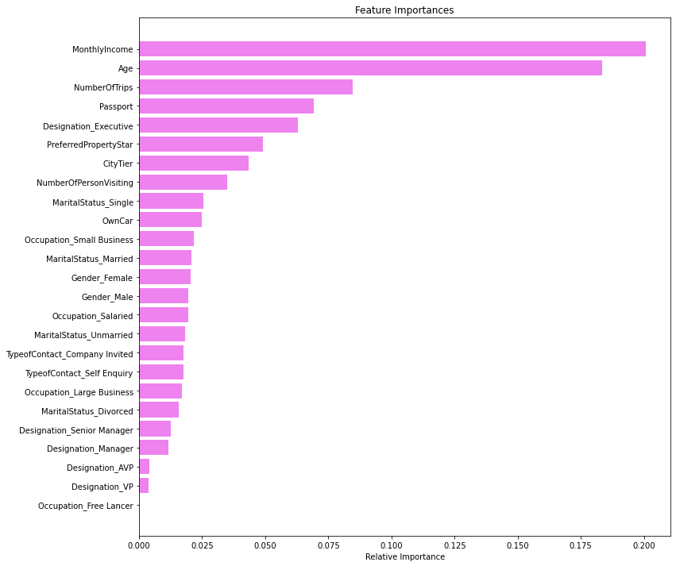

```python
feature_names = X_train.columns
importances = rf_tuned.feature_importances_
indices = np.argsort(importances)

plt.figure(figsize=(12, 12))
plt.title("Feature Importances")
plt.barh(range(len(indices)), importances[indices], color="violet", align="center")
plt.yticks(range(len(indices)), [feature_names[i] for i in indices])
plt.xlabel("Relative Importance")
plt.show()
```

Observations

- Monthly Income is the most important feature in identifying a customer who could be a potential customer for purchasing a travel package
- The next important features are Age, and Numberof Trips, Passport etc

## 7 Boosting Models

### Adaptive Boosting

```python
#Fitting the model
ab_classifier = AdaBoostClassifier(random_state=1)
ab_classifier.fit(X_train,y_train)
```

```
AdaBoostClassifier(random_state=1)
```

```python
# Using above defined function to get accuracy, recall and precision on train and test set
ab_score = get_metrics_score(ab_classifier)
```

```
Accuracy on training set :  0.8519388954171563
Accuracy on test set :  0.8450993831391364
Recall on training set :  0.32398753894080995
Recall on test set :  0.3054545454545455
Precision on training set :  0.7482014388489209
Precision on test set :  0.7058823529411765
```

Observation

- Though we have higher values for Accuracy on Training and Testing set, Recall values are low

### Gradient Boosting

```python
# Fitting the model
gb_classifier = GradientBoostingClassifier(random_state=1)
gb_classifier.fit(X_train, y_train)
```

```
GradientBoostingClassifier(random_state=1)
```

```python
gb_score = get_metrics_score(gb_classifier)
```

```
Accuracy on training set :  0.8845475910693302
Accuracy on test set :  0.86223440712817
Recall on training set :  0.4750778816199377
Recall on test set :  0.4109090909090909
Precision on training set :  0.8448753462603878
Precision on test set :  0.743421052631579
```

Observation

- Recall values have only slightly increased compared to AdaBoosting

### XGBoost

```python
#Fitting the model
xgb_classifier = XGBClassifier(random_state=1, eval_metric='logloss')
xgb_classifier.fit(X_train,y_train)
```

```
XGBClassifier(base_score=0.5, booster='gbtree', colsample_bylevel=1,
              colsample_bynode=1, colsample_bytree=1, enable_categorical=False,
              eval_metric='logloss', gamma=0, gpu_id=-1, importance_type=None,
              interaction_constraints='', learning_rate=0.300000012,
              max_delta_step=0, max_depth=6, min_child_weight=1, missing=nan,
              monotone_constraints='()', n_estimators=100, n_jobs=8,
              num_parallel_tree=1, predictor='auto', random_state=1,
              reg_alpha=0, reg_lambda=1, scale_pos_weight=1, subsample=1,
              tree_method='exact', validate_parameters=1, verbosity=None)
```

```python
xgb_score = get_metrics_score(xgb_classifier)
```

```
Accuracy on training set :  0.9964747356051704
Accuracy on test set :  0.9013022618231665
Recall on training set :  0.9813084112149533
Recall on test set :  0.6290909090909091
Precision on training set :  1.0
Precision on test set :  0.8046511627906977
```

Observation

- Recall values of training and test have significantly improved , compared to previous Boosting Models

### Stacking Classifier

```python
estimators = [
    ("Random Forest Tuned", rf_tuned),
    ("Gradient Boosting", gb_classifier),
    ("Decision Tree", dtree),
]

final_estimator = xgb_classifier

stacking_classifier = StackingClassifier(
    estimators=estimators, final_estimator=final_estimator
)

stacking_classifier.fit(X_train, y_train)
```

```
StackingClassifier(estimators=[('Random Forest Tuned',
                                RandomForestClassifier(max_features=0.9,
                                                       n_estimators=501,
                                                       random_state=1)),
                               ('Gradient Boosting',
                                GradientBoostingClassifier(random_state=1)),
                               ('Decision Tree',
                                DecisionTreeClassifier(random_state=1))],
                   final_estimator=XGBClassifier(base_score=0.5,
                                                 booster='gbtree',
                                                 colsample_bylevel=1,
                                                 colsample_bynode=1,
                                                 co...
                                                 importance_type=None,
                                                 interaction_constraints='',
                                                 learning_rate=0.300000012,
                                                 max_delta_step=0, max_depth=6,
                                                 min_child_weight=1,
                                                 missing=nan,
                                                 monotone_constraints='()',
                                                 n_estimators=100, n_jobs=8,
                                                 num_parallel_tree=1,
                                                 predictor='auto',
                                                 random_state=1, reg_alpha=0,
                                                 reg_lambda=1,
                                                 scale_pos_weight=1,
                                                 subsample=1,
                                                 tree_method='exact',
                                                 validate_parameters=1,
                                                 verbosity=None))
```

```python
stacking_score = get_metrics_score(stacking_classifier)
```

```
Accuracy on training set :  0.9923619271445359
Accuracy on test set :  0.9054146675805346
Recall on training set :  0.9937694704049844
Recall on test set :  0.7054545454545454
Precision on training set :  0.9666666666666667
Precision on test set :  0.7729083665338645
```

Observation

- Recall on testing set has significantly improved in the Stacking Model

## 8 Boosting Models Tuned

- using HyperParameter Tuning with GridSearchCV

### Adaptive Booster Tuned

```python
# Choose the type of classifier.
abc_tuned = AdaBoostClassifier(random_state=1)

# Grid of parameters to choose from
parameters = {
    # Let's try different max_depth for base_estimator
    "base_estimator": [
        DecisionTreeClassifier(max_depth=1),
        DecisionTreeClassifier(max_depth=2),
        DecisionTreeClassifier(max_depth=3),
    ],
    "n_estimators": np.arange(10, 110, 10),
    "learning_rate": np.arange(0.1, 2, 0.1),
}

# Type of scoring used to compare parameter  combinations
scorer = metrics.make_scorer(metrics.recall_score)

# Run the grid search
grid_obj = GridSearchCV(abc_tuned, parameters, scoring=scorer, cv=5)
grid_obj = grid_obj.fit(X_train, y_train)

# Set the clf to the best combination of parameters
abc_tuned = grid_obj.best_estimator_

# Fit the best algorithm to the data.
abc_tuned.fit(X_train, y_train)
```

```
AdaBoostClassifier(base_estimator=DecisionTreeClassifier(max_depth=3),
                   learning_rate=1.1, n_estimators=100, random_state=1)
```

```python
abc_score = get_metrics_score(abc_tuned)
```

```
Accuracy on training set :  0.9759106933019976
Accuracy on test set :  0.8519533927347498
Recall on training set :  0.9096573208722741
Recall on test set :  0.5418181818181819
Precision on training set :  0.9605263157894737
Precision on test set :  0.6234309623430963
```

Observation

- Recall values are good compared to the regular Adaptive Booster

### Gradient Booster Tuned

```python
# Choose the type of classifier.
gbc_tuned = GradientBoostingClassifier(
    init=AdaBoostClassifier(random_state=1), random_state=1
)

# Grid of parameters to choose from
parameters = {
    "n_estimators": [100, 150, 200, 250],
    "subsample": [0.8, 0.9, 1],
    "max_features": [0.7, 0.8, 0.9, 1],
}

# Type of scoring used to compare parameter combinations
scorer = metrics.make_scorer(metrics.recall_score)

# Run the grid search
grid_obj = GridSearchCV(gbc_tuned, parameters, scoring=scorer, cv=5)
grid_obj = grid_obj.fit(X_train, y_train)

# Set the clf to the best combination of parameters
gbc_tuned = grid_obj.best_estimator_

# Fit the best algorithm to the data.
gbc_tuned.fit(X_train, y_train)
```

```
GradientBoostingClassifier(init=AdaBoostClassifier(random_state=1),
                           max_features=0.8, n_estimators=250, random_state=1,
                           subsample=1)
```

```python
gbc_score = get_metrics_score(gbc_tuned)
```

```
Accuracy on training set :  0.9106933019976499
Accuracy on test set :  0.8725154215215901
Recall on training set :  0.5716510903426791
Recall on test set :  0.46545454545454545
Precision on training set :  0.9267676767676768
Precision on test set :  0.7664670658682635
```

Observation

- Recall Values and Accuracy have improved compared to the regular Gradient Booster

(Xtreme Boosting Tuning is not attempted here due to significantly longer run time)

### Comparing Results of Boosting Models

```python
# defining list of models
models = [
    ab_classifier,
    abc_tuned,
    gb_classifier,
    gbc_tuned,
    xgb_classifier,
    stacking_classifier,
]

# defining empty lists to add train and test results
acc_train = []
acc_test = []
recall_train = []
recall_test = []
precision_train = []
precision_test = []

# looping through all the models to get the accuracy, precall and precision scores
for model in models:
    j = get_metrics_score(model, False)
    acc_train.append(np.round(j[0], 2))
    acc_test.append(np.round(j[1], 2))
    recall_train.append(np.round(j[2], 2))
    recall_test.append(np.round(j[3], 2))
    precision_train.append(np.round(j[4], 2))
    precision_test.append(np.round(j[5], 2))
```

```python
comparison_frame = pd.DataFrame(
    {
        "Model": [
            "Adaptive Boosting",
            "Adaptive Boosting Tuned",
            "Gradient Boosting",
            "Gradient BoostingTuned",
            "Xtreme Gradient Boosting",
            "Stacking classifier",
        ],
        "Train_Accuracy": acc_train,
        "Test_Accuracy": acc_test,
        "Train_Recall": recall_train,
        "Test_Recall": recall_test,
        "Train_Precision": precision_train,
        "Test_Precision": precision_test,
    }
)
comparison_frame
```

|  | Model | Train_Accuracy | Test_Accuracy | Train_Recall | Test_Recall | Train_Precision | Test_Precision |
| --- | --- | --- | --- | --- | --- | --- | --- |
| 0 | Adaptive Boosting | 0.85 | 0.85 | 0.32 | 0.31 | 0.75 | 0.71 |
| 1 | Adaptive Boosting Tuned | 0.98 | 0.85 | 0.91 | 0.54 | 0.96 | 0.62 |
| 2 | Gradient Boosting | 0.88 | 0.86 | 0.48 | 0.41 | 0.84 | 0.74 |
| 3 | Gradient BoostingTuned | 0.91 | 0.87 | 0.57 | 0.47 | 0.93 | 0.77 |
| 4 | Xtreme Gradient Boosting | 1.00 | 0.90 | 0.98 | 0.63 | 1.00 | 0.80 |
| 5 | Stacking classifier | 0.99 | 0.91 | 0.99 | 0.71 | 0.97 | 0.77 |

Observation